# Modélisation statistique

Les modèles d’analyse prédictive sont des algorithmes statistiques ou d’apprentissage automatique qui utilisent des données historiques pour prédire des événements ou des comportements futurs. Ces modèles analysent de grandes quantités de données pour identifier des tendances et des modèles, qu’ils utilisent ensuite pour prévoir des résultats futurs.

Ils peuvent être classés en plusieurs types, notamment :

- **Les modèles de régression** : ces modèles utilisent une ou plusieurs variables d’entrée pour prédire une valeur numérique continue, telle que le chiffre d’affaires ou la valeur à vie du client.
- **Les modèles de classification** : utilisés pour catégoriser les données en deux ou plusieurs groupes en fonction des variables d’entrée. La détection de fraude, la segmentation de la clientèle et le filtrage des spams sont quelques exemples.
- **Les modèles de série temporelle** : ils sont utilisés pour prédire les valeurs futures en fonction des tendances et des motifs historiques dans des *données où chaque observation est enregistrée à des moments spécifiques et est ordonnée selon une séquence chronologique*, tels que les prix des actions, les modèles météorologiques ou le trafic sur le site web.
- **Les modèles de regroupement** : ils sont utilisés pour catégoriser les points de données en fonction de leurs caractéristiques ou de leurs comportements similaires. Les modèles de regroupement, qui relèvent de l’Unsupervised learning, sont souvent utilisés pour la segmentation de la clientèle et l’analyse du panier d’achat.
- **Les modèles de réseau neuronal** : ils sont conçus pour identifier des motifs complexes et des relations non linéaires dans les données à l’aide de réseaux de neurones artificiels. Ces modèles sont largement utilisés dans diverses applications telles que la reconnaissance d’images et de la parole, le traitement du langage naturel, et la maintenance prédictive. Grâce à leur capacité à apprendre et à généraliser à partir de grandes quantités de données, les réseaux neuronaux sont particulièrement efficaces pour résoudre des problèmes où les interactions entre les variables sont complexes et difficiles à modéliser avec des approches traditionnelles.
- **Les arbres de décision** : ils sont utilisés pour générer une représentation visuelle des résultats possibles en fonction de différents chemins de décision. Ils sont fréquemment utilisés pour évaluer les risques, détecter la fraude et analyser la rétention de la clientèle.
- **Les modèles d’ensemble** : ils *combinent plusieurs modèles prédictifs* pour améliorer l’exactitude tout en réduisant le risque de suradaptation. Les forêts aléatoires, le boosting de gradient et les modèles d’empilement sont quelques exemples.

## Application de ces modèles

- **Finance** : En finance, les modèles d’analyse prédictive sont utilisés pour prévoir les prix des actions, les risques de crédit et d’autres métriques financières. Ces modèles sont utilisés par les banques et les institutions financières pour identifier les risques et les opportunités potentiels.
- **Santé** : Dans le domaine de la santé, ils sont utilisés pour prévoir les résultats des maladies, identifier les patients à haut risque et améliorer les résultats des patients. Les hôpitaux et les prestataires de soins de santé utilisent ces modèles pour améliorer les soins aux patients tout en réduisant les coûts.
- **Marketing** : Le marketing utilise des modèles d’analyse prédictive pour identifier les répartitions de clients, prévoir le comportement des clients et optimiser les campagnes marketing. Ca aide à améliorer l’engagement des clients et les ventes.
- **Fabrication** : On les utilise dans la fabrication pour prévoir les pannes d’équipement, optimiser les processus de production et réduire les temps d’arrêt. Les fabricants utilisent ces modèles pour augmenter l’efficacité et réduire les coûts.
- **Commerce de détail** : Les détaillants utilisent des modèles d’analyse prédictive pour prévoir la demande des clients, optimiser les niveaux de stock et améliorer les stratégies de tarification.

## Limites des modèles d’analyse prédictive

Bien que les modèles prédictifs offrent assez d’avantages, ils ont également certaines limites. Voici quelques-unes des principales limites :

- **Les prédictions précises reposent sur des données précises et complètes** : les modèles d’analyse prédictive reposent fortement sur les données historiques. Si les données utilisées pour construire le modèle sont inexactes ou incomplètes, cela peut conduire à des prédictions peu fiables.
- **Les modèles prédictifs prennent rarement en compte les valeurs aberrantes** : les modèles d’analyse prédictive peuvent ne pas être en mesure de prendre en compte les événements imprévus ou les valeurs aberrantes. Comme ces événements n’ont peut-être pas eu lieu dans les données historiques entrées, le modèle prédictif ne sera pas en mesure de prédire avec précision les valeurs aberrantes.

### 1. Modèles de régression

#### 1.1. **Régression linéaire** :

Le but de la régression simple (resp. multiple) est d’expliquer une variable Y à l’aide d’une variable X (resp. plusieurs variables X1, …, Xq). La variable Y est appelée variable dépendante, ou variable à expliquer et les variables Xj (j=1,…,q) sont appelées variables indépendantes, ou variables explicatives.

Le modèle de régression le plus simple est l’ajustement affine. Celui-ci consiste à rechercher la droite permettant d’expliquer le comportement d’une variable statistique y comme étant une fonction affine d’une autre variable statistique x.

Soit le modèle probabiliste suivant :
$$y
= \beta_0+\beta_1x+\varepsilon$$
Le paramètre $\beta_0$ représente l’ordonnée à l’origine et $\beta_1$ le coefficient directeur de la droite; $\varepsilon$ le terme d’erreur

[output not shown]

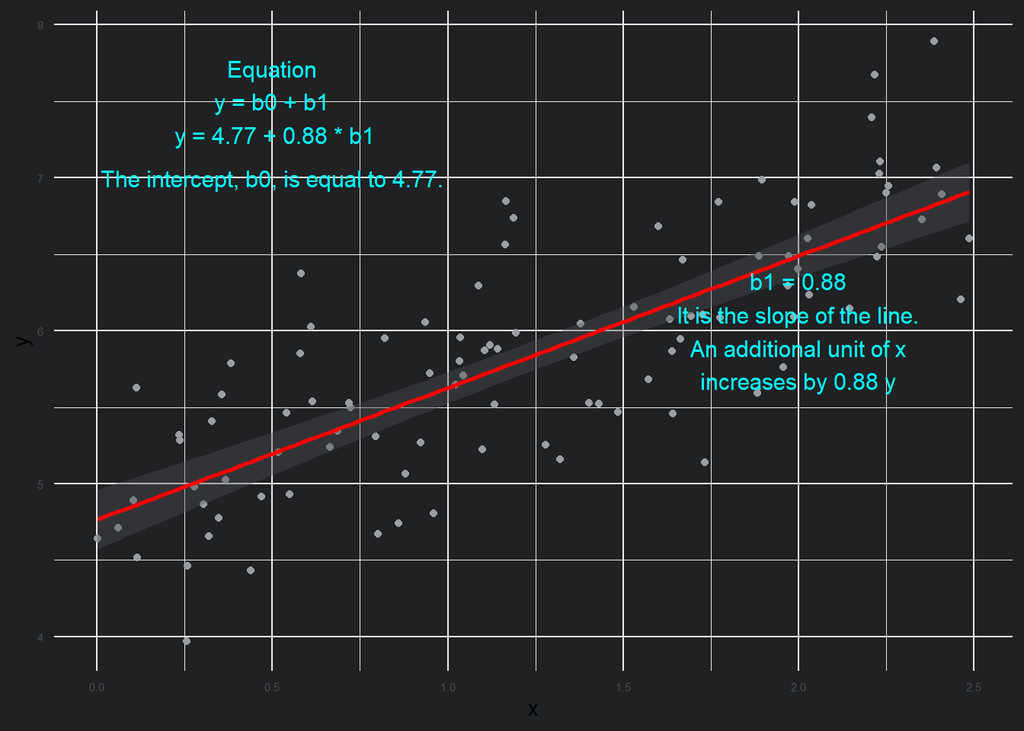

```r
library(ggplot2)
library(ggtext)
set.seed(123)
x <- runif(100, 0, 2.5)
y <- 4.77 + 0.88 * x + rnorm(100, 0, 0.5)

data <- data.frame(x = x, y = y)
ggplot(data, aes(x = x, y = y)) +
  geom_point() +
  geom_smooth(method = "lm", col = "red") +
  annotate("text", x = 0.5, y = 7.5, label = "Equation\n y = b0 + b1 \n y = 4.77 + 0.88 * b1", color = "cyan", size = 4) +
  annotate("text", x = 0.5, y = 7, label = "The intercept, b0, is equal to 4.77.", color = "cyan", size = 4) +
  annotate("text", x = 2, y = 6, label = "b1 = 0.88\nIt is the slope of the line.\nAn additional unit of x\nincreases by 0.88 y", color = "cyan", size = 4) +
  theme_minimal()
```

Allons y par étapes:

### 1.1.1 Analyse graphique

Quand faut-il supposer une régression linéaire ?

### 1.1.2 Modélisation

Notre modèle sera donc :
$$y = \beta_0 +
\beta_1 x + \varepsilon$$

### 1.1.3 Estimation des coefficients

Le modèle étant posé, il faut estimer numériquement les paramètres du modèle. Quelles valeurs des coefficients correspondent le mieux aux données ?

#### Méthode des moindres carrés :

L’objectif principal de la méthode des moindres carrés ordinaires (MCO) est la minimisation de la somme des carrés résiduelle. Ainsi,
$$\text{Minimiser} \sum_{i=1}^n
\varepsilon_i^2 = \sum_{i=1}^n (y_i - (\beta_0 + \beta_1 x_i))^2$$

Pour trouver les valeurs de $\beta_0$ et $\beta_1$ qui minimisent cette somme, nous procédons par dérivation partielle et résolution des équations normales.

1. **Formuler la fonction de coût :**
   $$S(\beta_0, \beta_1) = \sum_{i=1}^n (y_i -
   (\beta_0 + \beta_1 x_i))^2$$
2. **Dériver par rapport à** $\beta_0$ et $\beta_1$ :
   $$\frac{\partial S}{\partial \beta_0} = -2 \sum_{i=1}^n (y_i - (\beta_0 +
   \beta_1 x_i))$$
   $$\frac{\partial
   S}{\partial \beta_1} = -2 \sum_{i=1}^n x_i (y_i - (\beta_0 + \beta_1
   x_i))$$
3. **Équations normales :**
   $$\sum_{i=1}^n (y_i - \beta_0 - \beta_1 x_i) = 0$$
   $$\sum_{i=1}^n x_i (y_i - \beta_0
   - \beta_1 x_i) = 0$$
4. **Résolution des équations normales :**

   De la première équation normale :
   $$\sum_{i=1}^n y_i = n \beta_0 + \beta_1 \sum_{i=1}^n x_i$$
   $$\beta_0 = \bar{y} - \beta_1 \bar{x}$$
   où $\bar{y}$ et $\bar{x}$ sont les moyennes de $y$ et $x$ respectivement.

   De la deuxième équation normale :
   $$\sum_{i=1}^n x_i y_i = \beta_0 \sum_{i=1}^n x_i + \beta_1 \sum_{i=1}^n
   x_i^2$$
   En substituant $\beta_0$ dans cette équation, nous obtenons :
   $$\sum_{i=1}^n x_i y_i = (\bar{y}
   - \beta_1 \bar{x}) \sum_{i=1}^n x_i + \beta_1 \sum_{i=1}^n x_i^2$$

   Simplification de cette équation donne :
   $$\sum_{i=1}^n x_i y_i = \bar{y} \sum_{i=1}^n x_i
   + \beta_1 (\sum_{i=1}^n x_i^2 - \sum_{i=1}^n x_i \bar{x})$$
   $$\sum_{i=1}^n x_i y_i - \bar{y}
   \sum_{i=1}^n x_i = \beta_1 (\sum_{i=1}^n x_i^2 - n \bar{x}^2)$$
   $$\beta_1 = \frac{\sum_{i=1}^n (x_i -
   \bar{x})(y_i - \bar{y})}{\sum_{i=1}^n (x_i - \bar{x})^2}$$
5. **Formules finales pour** $\beta_0$ et $\beta_1$ :
   $$\beta_1 = \frac{\sum_{i=1}^n (x_i - \bar{x})(y_i -
   \bar{y})}{\sum_{i=1}^n (x_i - \bar{x})^2}$$
   $$\beta_0 = \bar{y} - \beta_1 \bar{x}$$

Ces formules permettent de calculer les coefficients $\beta_0$ et $\beta_1$ qui minimisent la somme des carrés des résidus pour un modèle de régression linéaire simple.

#### 1.1.4 Vérification des hypothèses

1. **Linéarité** : La relation entre les variables indépendantes et dépendantes doit être linéaire.
2. **Homoscédasticité** : Les résidus doivent avoir une variance constante.
3. **Indépendance des erreurs** : Les résidus doivent être indépendants les uns des autres.
4. **Normalité des résidus** : Les résidus doivent suivre une distribution normale.

```python
import numpy as np
import matplotlib.pyplot as plt
import seaborn as sns
from sklearn.linear_model import LinearRegression
from scipy import stats
from statsmodels.stats.diagnostic import het_breuschpagan
```

```python
N = 300
np.random.seed(0)
x = np.random.rand(N) * 10
y = 2.5 * x + np.random.randn(N) * 2 + 5
```

```python
# Ajuster le modèle de régression linéaire
model = LinearRegression()
model.fit(x.reshape(-1, 1), y)
```

```
LinearRegression()
```

```python
y_pred = model.predict(x.reshape(-1, 1))

# Calculer les résidus
residuals = y - y_pred
```

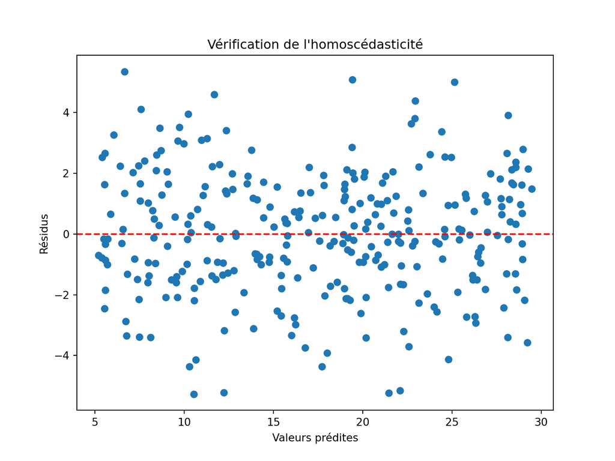

```python
# Vérification de l'homoscédasticité
plt.figure(figsize=(8, 6))
plt.scatter(y_pred, residuals)
plt.axhline(y=0, color='red', linestyle='--')
plt.xlabel('Valeurs prédites')
plt.ylabel('Résidus')
plt.title('Vérification de l\'homoscédasticité')
plt.show()
```

```python
# Test de Breusch-Pagan pour l'homoscédasticité
exog = np.column_stack((np.ones(len(x)), x))
bp_test = het_breuschpagan(residuals, exog)
labels = ['LM Stat', 'LM Test p-value', 'F-Stat', 'F-Test p-value']
print(dict(zip(labels, bp_test)))
```

```
## {'LM Stat': 1.009439631189235, 'LM Test p-value': 0.31503712345959434, 'F-Stat': 1.0060953420179428, 'F-Test p-value': 0.31665385927831774}
```

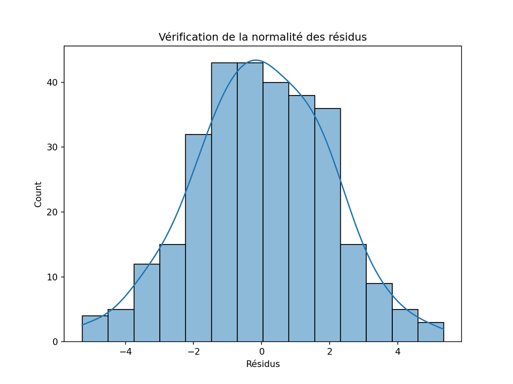

```python
# Vérification de la normalité des résidus
plt.figure(figsize=(8, 6))
sns.histplot(residuals, kde=True)
plt.xlabel('Résidus')
plt.title('Vérification de la normalité des résidus')
plt.show()
```

```python
# Test de normalité de Shapiro-Wilk
shapiro_test = stats.shapiro(residuals)
print(f'Test de Shapiro-Wilk: Statistique={shapiro_test[0]}, p-value={shapiro_test[1]}')
```

```
## Test de Shapiro-Wilk: Statistique=0.9970179480327056, p-value=0.8565201568303873
```